# DTW examples for Covid-19 datasets for ECDC

toni.giorgino@cnr.it - CNR Institute of Biophysics & Dept. of Biosciences UniMi

Tue Nov 3 15:29:47 2020

# 1 Generalities (which can be deleted)

# 2 Data loading

Note: check if the COVID19 package https://cran.r-project.org/web/packages/COVID19/index.html has similar data and it is more convenient.

```r
library(dplyr)
library(dtw)
library(readxl)
```

Load all sheets in list elements. **Important**: sort by dates.

```r
xn <- "example_data.xlsx"
countries <- excel_sheets(xn)
Ncountries <- length(countries)

data<-list()
for (c in countries) {
        data[[c]] <- read_excel(xn, sheet=c)  %>% arrange(Date)
}
```

# 3 Preprocessing and test alignment

Just one test alignment, for demonstration purposes. **Note.** Using columns as-is is probably simplistic, because columns may have different lags depending on the local country characteristics (e.g. infection-to-report delays, which may not even be constant).

The columns must be be matched, of course (e.g. column 1 is new cases for all countries).

Here I define a preprocessing function which returns a matrix. The preprocessing includes scaling. This implies that columns will get the same “weight” - which may not be desirable! If different weights are desired, just multiply the columns.

```r
df.preprocess <- function(df) {
        tmp <- df %>% select(New_Cases, New_Deaths, Daily_Incidence) %>% as.matrix
        tmp[is.na(tmp)] <- 0   # NAs become 0
        sc <- scale(tmp)  # Standardize by column
        sc
}

tmp.at <- df.preprocess(data[["Austria"]])
tmp.fr <- df.preprocess(data[["France"]])

dtw.at.fr <- dtw(tmp.at, tmp.fr)  # The most basic format, all default parameters.
```

The alignment (warping function, or path) can be visualized as follows. Below or above diagonal means that the outbreak in one country occurs before or after the other.

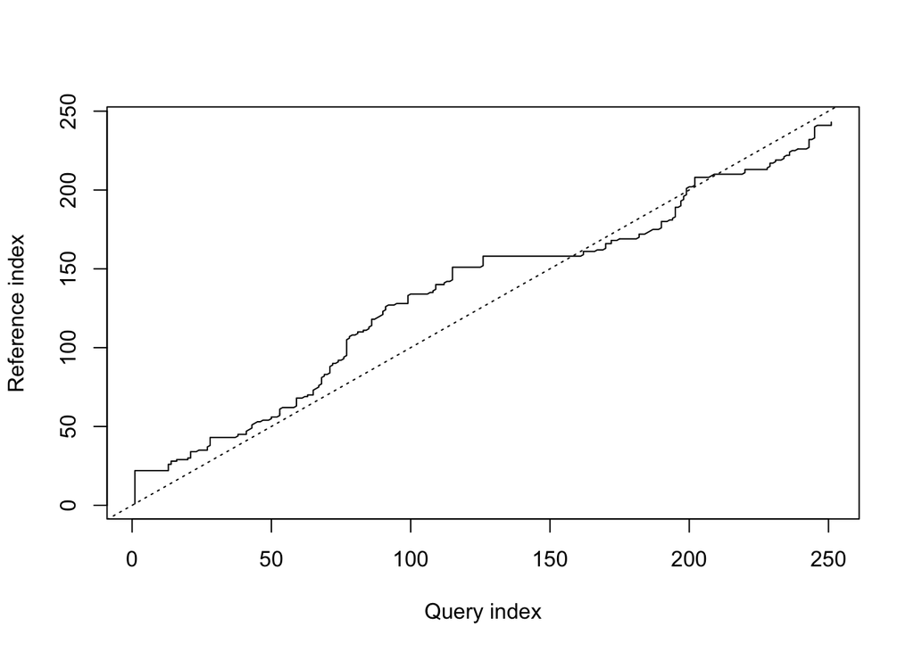

```r
plot(dtw.at.fr)

abline(a=0, b=1, lty=3)
```

This is the distance (dissimilarity) to be used in clustering

```r
dtw.at.fr$normalizedDistance
```

```
## [1] 0.3470184
```

# 4 All-vs-all alignment

Now compute the all-vs-all dissimilarity matrix via DTW. Note that the default `step.pattern=symmetric2` which gives a symmetric distance matrix. This is not true in general.

```r
dmat <- matrix(NA, nrow=Ncountries, ncol=Ncountries)
colnames(dmat) <- countries
rownames(dmat) <- countries

for (c1 in countries) {
        pp.c1 <- df.preprocess(data[[c1]])
        for (c2 in countries) {
                pp.c2 <- df.preprocess(data[[c2]])
                aln <- dtw(pp.c1, pp.c2, distance.only = T)
                dmat[c1,c2] <- aln$normalizedDistance
        }
}

dmat
```

```
##            France    Greece   Austria
## France  0.0000000 0.4782099 0.3470184
## Greece  0.4782099 0.0000000 0.4129965
## Austria 0.3470184 0.4129965 0.0000000
```

# 5 Clustering

Now any hierarchical algorithm may be used.

```r
dist.dmat <- as.dist(dmat)
hclust(dist.dmat)
```

```
##
## Call:
## hclust(d = dist.dmat)
##
## Cluster method   : complete
## Number of objects: 3
```